# Support Vector Machines: Exercise solutions

Course: Machine Learning II, Data Science Master (Universidad de Cantabria - UIMP).  
Author: Steven Van Vaerenbergh.

```python
import numpy as np
import matplotlib.pyplot as plt
from sklearn import datasets
from sklearn.svm import SVC
from sklearn.metrics import accuracy_score

# inline plots
%matplotlib inline
```

## Exercise: Iris Dataset

Apply an SVM classifier on the complete 4-dimensional Iris data set (2 classes only).

1. Construct the data. Choose a training size of 70% of the data.
2. Choose a kernel and run the SVM classifier on the training data.
3. Calculate the evaluation accuracy on the test data. Adjust the kernel parameters to maximize the accuracy.
4. [Bonus] Make a 3D plot of the results. Use a 3D scatter plot to draw the data, and indicate misclassified test data with crosses.

```python
# 1. Data

from sklearn.model_selection import train_test_split

iris = datasets.load_iris()
X = iris.data
y = iris.target

# remove class 0
X = X[y != 0]
y = y[y != 0]
y[y==2] = 0

print('Size of X is: '+str(X.shape))

# fraction of the data to assign to the test set
test_size = 0.3

X_train, X_test, y_train, y_test = train_test_split(
    X, y, test_size=test_size, random_state=0)

print('Size of X_train is: '+str(X_train.shape))
print('Size of X_test is: '+str(X_test.shape))
```

```
Size of X is: (100, 4)
Size of X_train is: (70, 4)
Size of X_test is: (30, 4)
```

```python
# 2. SVM

clf = SVC(kernel='rbf', C=1, gamma=10)
clf = SVC(kernel='linear')
clf.fit(X_train, y_train)
```

```
SVC(C=1.0, cache_size=200, class_weight=None, coef0=0.0,
  decision_function_shape='ovr', degree=3, gamma='auto_deprecated',
  kernel='linear', max_iter=-1, probability=False, random_state=None,
  shrinking=True, tol=0.001, verbose=False)
```

```python
# 3. Evaluate

# evaluation
y_pred = clf.predict(X_test)

print('Accuracy: %.2f%%'%(accuracy_score(y_test, y_pred)))
```

```
Accuracy: 0.93%
```

```python
# 4. [Bonus] 3D plot

# Install a pip package in the current Jupyter kernel
import sys
!{sys.executable} -m pip install plotly

# load Plotly
from plotly.offline import download_plotlyjs, init_notebook_mode, iplot
import plotly.graph_objs as go

# initiate the Plotly Notebook mode
init_notebook_mode(connected=True)
```

```python
def configure_data(X, y, symbol='circle', name='data'):
    # Marker symbols: https://plot.ly/python/reference/#scatter-marker

    # retrieve indices of zeroes and ones
    idx0 = y==0
    idx1 = y==1

    # define data set 1 plot options
    trace0 = go.Scatter3d(x=X[idx0,0], y=X[idx0,1], z=X[idx0,2],
        mode='markers',
        marker=dict(size=6, symbol=symbol, color='blue', opacity=0.6),
        name="%s 0"%name
    )

    # define data set 2 plot options
    trace1 = go.Scatter3d(x=X[idx1,0], y=X[idx1,1], z=X[idx1,2],
        mode='markers',
        marker=dict(size=6, symbol=symbol, color='red', opacity=0.6),
        name="%s 1"%name
    )

    return [trace0,trace1]

def plot_3D(data):

    # set aspect ratio
    scene = dict(aspectmode="manual", aspectratio=dict(x=1, y=1, z=1))

    # define figure properties
    layout = go.Layout(
        scene=scene,
        height=600,
        width=900
    )

    # produce the plot
    fig = go.Figure(data=data,layout=layout)
    iplot(fig)

# find misclassified data
idx_correct = y_test == y_pred

[trace0,trace1] = configure_data(X_train,y_train,name='Train')
[trace2,trace3] = configure_data(X_test[idx_correct,:],y_test[idx_correct],symbol='square-open',name='Test correct')
[trace4,trace5] = configure_data(X_test[~idx_correct],y_test[~idx_correct],symbol='x',name='Test errors')

plot_3D([trace0,trace1,trace2,trace3,trace4,trace5])
```

[interactive chart not shown]

## Exercise: Face Recognition

In the previous example we have chosen a number of principal components by hand. In order to find suitable parameters for the SVM, we have applied a grid search in which for each set of parameter values we have ran a cross-validation procedure to determine the fitness of the parameters. In this exercise you will extend the gird search to the number of principal components, using the [Pipeline class](http://scikit-learn.org/stable/modules/generated/sklearn.pipeline.Pipeline.html) from scikit-learn.

1. Build a classifier that consists of a pipeline of PCA and the support vector classifier.
2. Define a grid containing the values to consider for each of the parametres:
   - 3 values for PCA's `n_components`
   - 3 values for SVC's `C`
   - 3 values for SVC's `gamma`
3. Use GridSearchCV to find the best set of values for these 3 parameters.
4. Apply the classifier with the best parameters to the test set and plot the `classification_report` and the `confusion_matrix`.

```python
#!/usr/bin/env python -W ignore::DeprecationWarning
from sklearn.datasets import fetch_lfw_people
faces = fetch_lfw_people(min_faces_per_person=60)

X_train, X_test, y_train, y_test = train_test_split(faces.data, faces.target,
                                                    random_state=0)
```

```python
# 1. Pipeline

from sklearn.pipeline import make_pipeline
from sklearn.decomposition import PCA

pca = PCA(whiten=True, svd_solver='randomized', random_state=0)
svc = SVC(kernel='rbf', class_weight='balanced')
pipe = make_pipeline(pca, svc)
```

```python
# 2. Define grid for GridsearchCV

param_grid = {'pca__n_components': [50, 100, 150],
              'svc__C': [50, 100, 200],
              'svc__gamma': [0.001, 0.005, 0.01]}
```

```python
# 3. Run GridSearchCV

from sklearn.model_selection import GridSearchCV
from time import time

grid = GridSearchCV(pipe, param_grid, cv=3)

t0 = time()
grid.fit(X_train, y_train)

print("Elapsed time: %0.3fs"%(time() - t0))
print("Best estimator found by grid search:")
print(grid.best_params_)
```

```
Elapsed time: 68.456s
Best estimator found by grid search:
{'pca__n_components': 50, 'svc__C': 50, 'svc__gamma': 0.01}
```

```
                   precision    recall  f1-score   support

     Ariel Sharon       0.69      0.69      0.69        16
     Colin Powell       0.89      0.93      0.91        61
  Donald Rumsfeld       0.76      0.83      0.79        35
    George W Bush       0.85      0.91      0.88       125
Gerhard Schroeder       0.62      0.62      0.62        29
      Hugo Chavez       0.86      0.63      0.73        19
Junichiro Koizumi       0.93      0.76      0.84        17
       Tony Blair       0.79      0.63      0.70        35

        micro avg       0.82      0.82      0.82       337
        macro avg       0.80      0.75      0.77       337
     weighted avg       0.82      0.82      0.82       337
```

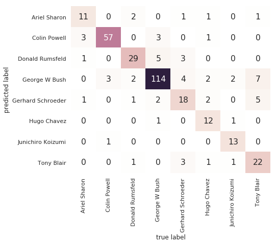

```python
# 4. Test the classifier

from sklearn.metrics import classification_report
from sklearn.metrics import confusion_matrix

# use seaborn plotting defaults
import seaborn as sns; sns.set()

clf = grid.best_estimator_

y_pred = clf.predict(X_test)

print(classification_report(y_test, y_pred, target_names=faces.target_names))

mat = confusion_matrix(y_test, y_pred)
fig, ax = plt.subplots(figsize=(7,6))
sns.set(font_scale=1.3)
sns.heatmap(mat.T, square=False, annot=True, fmt='d', cbar=False,
            xticklabels=faces.target_names,
            yticklabels=faces.target_names,
            cmap=sns.cubehelix_palette(light=1, as_cmap=True))

plt.xlabel('true label')
plt.ylabel('predicted label');
```